# Module 3, Lesson 3: Assessing the predictive ability of your model

In this independent guide, we will learn how to make predictions from a multiple logistic regression model, how to use different and complementary techniques to assess the quality of those predictions, and how assessing model fit using the same data as what was used to build the model will lead to optimism, i.e. a model that seems to be predicting more accurately than it actually is. As a consequence, we will see that it is desirable to assess your model’s predictive performance on a separate testing dataset.

To start, load the `healthds` and `tidyverse` packages in the usual way.

```r
library(healthds)
library(tidyverse)
```

At the end of Module 2, we fit a multiple logistic regression model predicting the risk of hypertension as a function of a person’s smoking status, age, body mass index (BMI), activity level, and salt intake. We fit this model to the `BPUrban300` data.

```r
htn_model <-
  glm(hypertension ~ smoking + age + bmi + activity + salt_group,
      family = "binomial",
      data = BPUrban300)
summary(htn_model)
```

```
##
## Call:
## glm(formula = hypertension ~ smoking + age + bmi + activity +
##     salt_group, family = "binomial", data = BPUrban300)
##
## Deviance Residuals:
##      Min        1Q    Median        3Q       Max
## -1.86269  -0.56618  -0.25836  -0.07201   2.82565
##
## Coefficients:
##                        Estimate Std. Error z value Pr(>|z|)
## (Intercept)           -11.71546    2.20001  -5.325 1.01e-07 ***
## smokingTRUE             1.58667    0.53500   2.966  0.00302 **
## age                     0.12859    0.02046   6.284 3.30e-10 ***
## bmi                     0.09998    0.05200   1.923  0.05454 .
## activitymoderate       -0.99278    0.51913  -1.912  0.05583 .
## activitymild           -0.41498    0.47682  -0.870  0.38413
## activitysevere         -0.71955    0.46529  -1.546  0.12199
## salt_group5<Salt<=10    0.13944    0.45929   0.304  0.76142
## salt_group10<Salt<=20   0.56542    0.54219   1.043  0.29702
## salt_groupSalt>20       0.73490    0.50518   1.455  0.14574
## ---
## Signif. codes:  0 '***' 0.001 '**' 0.01 '*' 0.05 '.' 0.1 ' ' 1
##
## (Dispersion parameter for binomial family taken to be 1)
##
##     Null deviance: 291.73  on 299  degrees of freedom
## Residual deviance: 205.05  on 290  degrees of freedom
## AIC: 225.05
##
## Number of Fisher Scoring iterations: 6
```

### Calibration plots

One technique for assessing predictions of binary outcomes is to categorize the observations into groups that are expected to have similar probabilities and then compare the predicted probabilities of that group against the observed proportion of the outcome within that group. This is sometimes called a calibration plot.

To make a calibration plot, we will use the `mutate` function to add a new variable to our `BPUrban300` data that represents each observation’s predicted probability of hypertension, according to the model. This is done using the `predict` function, which we’ve seen in Module 2 of this course. However, we will introduce here a new argument to `predict` called `newdata`, which allows one to provide a different dataset – that is, different from the one that we used to build the model – upon which to make predictions.

```r
BPUrban300 %>%
  mutate(pred_htn_prob = predict(htn_model, newdata = BPUrban300, type = "response")) %>%
  head()
```

```
##   hypertension systolic diastolic  bmi  bmi_group cholesterol age age_group
## 1            0      156        82 30.4  BMI>27.49         171  60     45-59
## 2            0       89        75 31.3  BMI>27.49         216  57     45-59
## 3            0      132        62 28.0  BMI>27.49         157  54     45-59
## 4            0       98        45 21.8 BMI<=27.49         117  75      >=60
## 5            0      101        76 28.4  BMI>27.49         205  71      >=60
## 6            0       57        78 35.0  BMI>27.49         200  33     30-44
##   parent_history_HTN salt  salt_group smoking chewing  activity weight
## 1               both  2.3     Salt<=5   FALSE    TRUE  moderate   77.0
## 2               none  5.8  5<Salt<=10   FALSE    TRUE      mild   75.8
## 3               none  8.7  5<Salt<=10   FALSE    TRUE sedentary   68.3
## 4               none  4.7     Salt<=5   FALSE   FALSE sedentary   55.1
## 5               none 19.8 10<Salt<=20   FALSE   FALSE      mild   80.5
## 6               none 19.9 10<Salt<=20    TRUE   FALSE  moderate   77.3
##   waist_circumference hip_circumference waist_hip_ratio fasting_glucose
## 1                98.0              95.6            1.02             172
## 2                75.6              75.7            1.00              53
## 3                72.0              77.3            0.93              86
## 4                67.2              60.6            1.11              53
## 5                69.1              87.6            0.79             117
## 6                85.5              90.0            0.95             124
##            caste marital_status religion  education gender pred_htn_prob
## 1 Schedule tribe        Married    Hindu >=Graduate Female    0.12415951
## 2    Other caste        Married     Sikh  <=Primary   Male    0.17767760
## 3        General        Married    Hindu >=Graduate Female    0.13789671
## 4        General        Married    Hindu       High   Male    0.52701995
## 5 Schedule caste        Married    Hindu     Middle   Male    0.59967686
## 6        General        Married    Hindu       High   Male    0.05659788
```

Above we show the first six rows of the augmented `BPUrban300` data, with the newly added variable, `pred_htn_prob`, being at the bottom right. Note that we have not saved this result as anything at this point. In particular, were we to look at the `BPUrban300` data, we would not see this newly added variable.

Next we are going to create a new variable `pred_htn_prob_cat` that categorizes the observations into ten equally sized groups based upon their predicted hypertension probabilities. We will use the `cut_number` function (available to us via `tidyverse`) to do so:

```r
BPUrban300 %>%
  mutate(pred_htn_prob = predict(htn_model, newdata = BPUrban300, type = "response")) %>%
  mutate(pred_htn_prob_cat = cut_number(pred_htn_prob, n = 10)) %>%
  head()
```

```
##   hypertension systolic diastolic  bmi  bmi_group cholesterol age age_group
## 1            0      156        82 30.4  BMI>27.49         171  60     45-59
## 2            0       89        75 31.3  BMI>27.49         216  57     45-59
## 3            0      132        62 28.0  BMI>27.49         157  54     45-59
## 4            0       98        45 21.8 BMI<=27.49         117  75      >=60
## 5            0      101        76 28.4  BMI>27.49         205  71      >=60
## 6            0       57        78 35.0  BMI>27.49         200  33     30-44
##   parent_history_HTN salt  salt_group smoking chewing  activity weight
## 1               both  2.3     Salt<=5   FALSE    TRUE  moderate   77.0
## 2               none  5.8  5<Salt<=10   FALSE    TRUE      mild   75.8
## 3               none  8.7  5<Salt<=10   FALSE    TRUE sedentary   68.3
## 4               none  4.7     Salt<=5   FALSE   FALSE sedentary   55.1
## 5               none 19.8 10<Salt<=20   FALSE   FALSE      mild   80.5
## 6               none 19.9 10<Salt<=20    TRUE   FALSE  moderate   77.3
##   waist_circumference hip_circumference waist_hip_ratio fasting_glucose
```

[output cut: 20 more lines]

The `cut_number` function turns a continuous variable (`pred_htn_prob` in this case) into a categorical variable. Because we have chosen to create `n = 10` categories, it will identify the 30 observations (30 being 10% of 300) that have the smallest predicted probabilities and put them into the first category, then the 30 observations that have the smallest predicted probabilities among those remaining and put them into the second category, and so forth. The label for `pred_htn_prob_cat` indicates the smallest and largest probabilities in each category; observations that have the same label are in the same group. So for example, the first person’s predicted probability of hypertension is 0.1242, meaning that they fall into the category corresponding to the interval (0.0884, 0.159].

Now we are going to group by this newly created categorical variable and calculate two numbers for each group: the average of the predicted hypertension probability and the observed proportion of individuals with hypertension:

```r
BPUrban300 %>%
  mutate(pred_htn_prob = predict(htn_model, newdata = BPUrban300, type = "response")) %>%
  mutate(pred_htn_prob_cat = cut_number(pred_htn_prob, n = 10)) %>%
  group_by(pred_htn_prob_cat) %>%
  summarize(avg_pred_htn_prob = mean(pred_htn_prob),
            avg_obs_htn = mean(hypertension))
```

```
## # A tibble: 10 × 3
##    pred_htn_prob_cat  avg_pred_htn_prob avg_obs_htn
##    <fct>                          <dbl>       <dbl>
##  1 [0.000823,0.00375]           0.00223      0
##  2 (0.00375,0.0104]             0.00664      0
##  3 (0.0104,0.0297]              0.0186       0.0667
##  4 (0.0297,0.0583]              0.0441       0.0333
##  5 (0.0583,0.0884]              0.0721       0.0667
##  6 (0.0884,0.159]               0.123        0.1
##  7 (0.159,0.255]                0.202        0.133
##  8 (0.255,0.403]                0.334        0.4
##  9 (0.403,0.512]                0.459        0.467
## 10 (0.512,0.824]                0.638        0.633
```

Generally speaking, we say that the model is calibrated if these two numbers are close within each group, and they seem to be. So, for example, the first row of these summarized data represents the group of 30 individuals with the smallest risk of hypertension. The average of these predicted risks in this first group is 0.0022, and the observed proportion of individuals in this group who actually are hypertensive is 0/30, or 0. Conversely, the average predicted risk in the highest-risk group is 0.638, and the observed proportion of individuals who are hypertensive is 19/30, or 0.633.

We can visualize these data using a simple scatterplot, adding the line $y=x$ to give a reference; the points from the scatterplot should fall close to this reference line if the the model is well-calibrated:

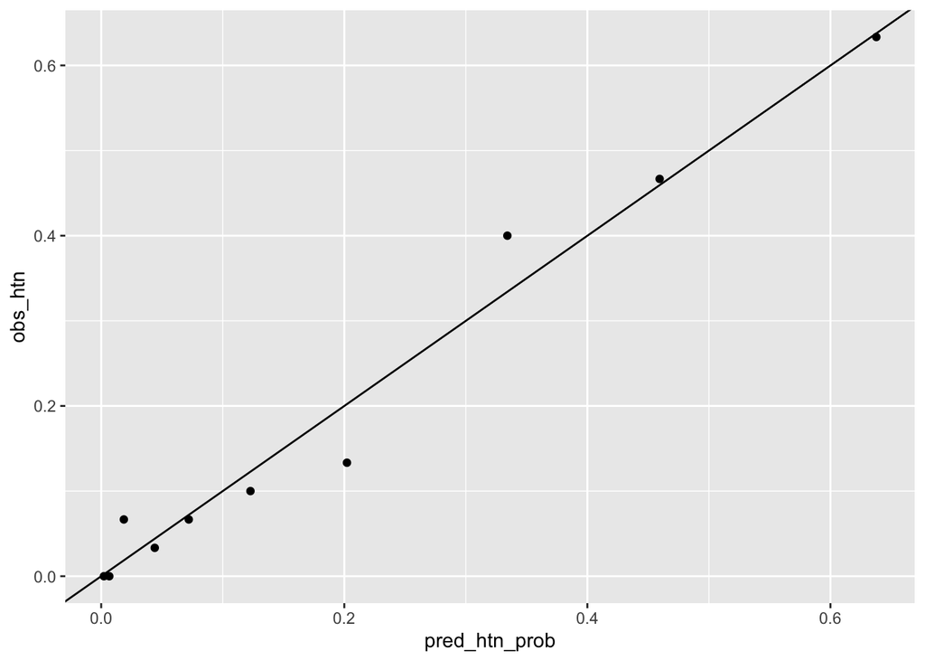

```r
BPUrban300 %>%
  mutate(pred_htn_prob = predict(htn_model, newdata = BPUrban300, type = "response")) %>%
  mutate(pred_htn_prob_cat = cut_number(pred_htn_prob, 10)) %>%
  group_by(pred_htn_prob_cat) %>%
  summarize(pred_htn_prob = mean(pred_htn_prob),
            obs_htn = mean(hypertension)) %>%
  ggplot() +
  geom_point(aes(x = pred_htn_prob, y = obs_htn)) +
  geom_abline(intercept = 0, slope = 1)
```

From this calibration plot, the model does indeed look well-calibrated, with the dots falling close to the reference line and not systematically above or below it. However, this assessment is likely too optimistic because we are assessing calibration on the same data that we used to build our model. A truer assessment would use data that our model has not ‘seen’ before. So, let us assess the calibration of this same model but now predicting hypertension in the `BPUrban1000` dataset:

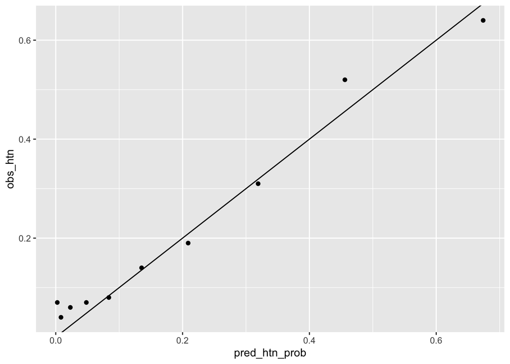

```r
BPUrban1000 %>%
  mutate(pred_htn_prob = predict(htn_model, newdata = BPUrban1000, type = "response")) %>%
  mutate(pred_htn_prob_cat = cut_number(pred_htn_prob, 10)) %>%
  group_by(pred_htn_prob_cat) %>%
  summarize(pred_htn_prob = mean(pred_htn_prob),
            obs_htn = mean(hypertension)) %>%
  ggplot() +
  geom_point(aes(x = pred_htn_prob, y = obs_htn)) +
  geom_abline(intercept = 0, slope = 1)
```

This plot has some hallmarks that we would expect when assessing calibration in a new dataset. Specifically, we see that among individuals who are predicted to be very low risk according to the model, i.e. less than 1% risk of hypertension, the observed proportion of those individuals who have hypertension is actually 4-7%. This might lead us to believe that our hypertension risk model is under-predicting the true risk of hypertension in this population. In general, when constructing a calibration plot for new data, you should expect to see dots fall farther from the $y=x$ line.

### Receiver-Operator Characteristic (ROC) curves and Area under the ROC curve (AUC)

The ROC curve is another way of assessing the predictive ability of a model. It is based on making classifications using predicted risk. So, for example, suppose we were to classify everyone with a predicted risk of 0.5 or greater as being hypertensive and everyone else as not being hypertensive. This approach would have a certain sensitivity, which is the probability of correctly classifying someone who in truth is hypertensive, and a certain specificity, which is the probability of correctly classifying someone who in truth is not hypertensive. Ideally sensitivity and specificity would both be high, with their best possible values being 1.

However, we could also make a classification based upon a threshold that is different from 0.5. For example, we could classify everyone with a predicted risk of 0.2 or greater as being hypertensive. By lowering this threshold, we will increase our sensitivity and decrease our specificity. Alternatively, we could increase this threshold, which would decrease our sensitivity and increase our specificity.

An ROC curve, then, is the plot of the resulting sensitivity against the resulting specificity for all possible thresholds (technically, the ROC curve plots sensitivity against *one minus specificity*, so that both values increase the threshold).

To create an ROC curve, we will need install and load a new R package called `pROC`.

```r
# Only run this code once per computer
install.packages("pROC")
```

```r
library(pROC)
```

Having done this, we will use the `roc` function from this package. This function requires a ‘gold standard’ (the truth), which is `hypertension` in our case, and a predicted risk (`pred_htn_prob`). It will take care of all of the actual calculations.

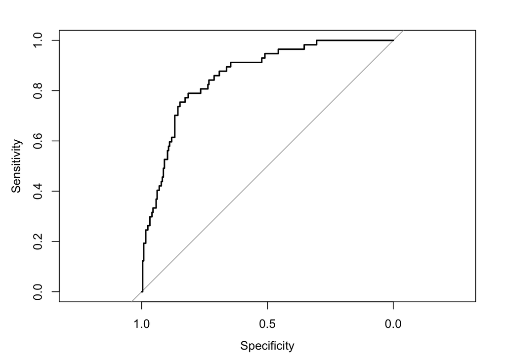

```
##
## Call:
## roc.data.frame(data = ., response = hypertension, predictor = pred_htn_prob,     plot = TRUE)
##
## Data: pred_htn_prob in 243 controls (hypertension 0) < 57 cases (hypertension 1).
## Area under the curve: 0.8594
```

```r
BPUrban300 %>%
  mutate(pred_htn_prob = predict(htn_model, newdata = BPUrban300, type = "response")) %>%
  roc(hypertension, pred_htn_prob, plot = TRUE)
```

W get some information in the console, which is helpful to ensure that the code is working as expected. We see that there are 243 controls in our data (those who are not hypertensive) and 57 cases (those who are hypertensive).

The Area under the ROC curve, or AUC, is the size of the region underneath the ROC curve. From the output in the console, our model has an AUC of 0.8594 in these data. An ideal AUC is 1, and the worst AUC is 0.5. The AUC is sometimes used as a single-number summary of an ROC curve. It also has a nice interpretation as being the probability that our model can correctly discriminate between higher and lower risk individuals. Specifically, given two individuals, one with hypertension and one without, the AUC can be interpreted as the probability that our model gives the individual with hypertension a higher risk of hypertension than the individual without hypertension.

As before, this assessment is optimistic because we are assessing our model on the same data as what was used to fit the model. A more honest assessment would use different data, e.g. the `BPUrban1000` data:

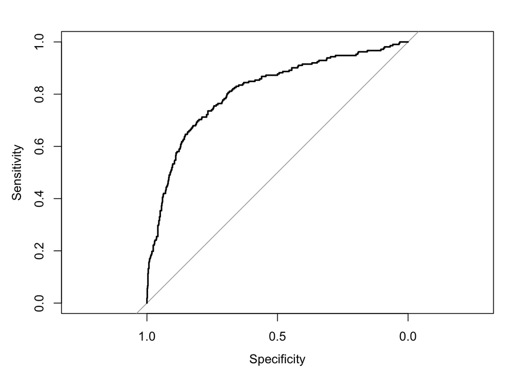

```
##
## Call:
## roc.data.frame(data = ., response = hypertension, predictor = pred_htn_prob,     plot = TRUE)
##
## Data: pred_htn_prob in 788 controls (hypertension 0) < 212 cases (hypertension 1).
## Area under the curve: 0.811
```

```r
BPUrban1000 %>%
  mutate(pred_htn_prob = predict(htn_model, newdata = BPUrban1000, type = "response")) %>%
  roc(hypertension, pred_htn_prob, plot = TRUE)
```

Having done so, the ROC curve is now somewhat closer to the $y=x$ reference line, and the value of the AUC has dropped from 0.8594 to 0.811; still large but not as large as before.

### Brier Scores

Brier scores are numerical summaries of your model’s predictive ability that combine elements of both calibration and discrimination.

The Brier score is defined as the average of the squared difference between an observation’s predicted probability (which can be any number between 0 and 1) and an observation’s actual outcome (coded as 0 for observations without the outcome and as 1 for observations with the outcome). The best possible Brier score is zero, corresponding to assigning a predicted probability of 1 to all individuals with the outcome and a predicted probability of 0 to all individuals without the outcome.

Separately, we are also interested in the maximum Brier score for our particular dataset, which is the Brier score that we would get if we used the observed prevalence of the outcome across all observations as a prediction for everyone. The maximum Brier score reflects a contextual upper bound on the Brier score for a particular situation.

Finally, the scaled Brier score is defined as one minus the ratio of the Brier score divided by the maximum Brier score. Whereas the Brier score ranges from 0 to whatever value the maximum Brier score is, with smaller numbers being preferred, the *scaled* Brier score ranges from 0 to 1, and larger values are preferred. A *scaled* Brier score of 1 corresponds to a Brier score of 0.

To calculate the Brier score and the maximum Brier score, we will use the `summarize` function. Interestingly, we won’t precede our call to `summarize` with a call to `group_by`. This is because we want to summarize across the entire dataset, not separately by any group. Then, having calculated these numbers, we can calculate the scaled Brier score using a call to `mutate`. Altogether, this is the result:

```r
BPUrban300 %>%
  mutate(pred_htn_prob = predict(htn_model, newdata = BPUrban300, type = "response")) %>%
  summarize(brier = mean((hypertension - pred_htn_prob)^2),
            brier_max = mean(hypertension) * (1 - mean(hypertension))) %>%
  mutate(scaled_brier = 1 - brier / brier_max)
```

```
##       brier brier_max scaled_brier
## 1 0.1085141    0.1539     0.294905
```

When applied to the same data used to fit the model, our model achieves a Brier score of 0.1085 and a scaled Brier score of 0.2949. Remember that 0 is the best possible Brier score and 1 is the best possible scaled Brier score. Now let us see what happens when we assess this model on the `BPUrban1000` data:

```r
BPUrban1000 %>%
  mutate(pred_htn_prob = predict(htn_model,  newdata = BPUrban1000, type = "response")) %>%
  summarize(brier = mean((hypertension - pred_htn_prob)^2),
            brier_max = mean(hypertension) * (1 - mean(hypertension))) %>%
  mutate(scaled_brier = 1 - brier / brier_max)
```

```
##       brier brier_max scaled_brier
## 1 0.1254144  0.167056    0.2492673
```

As we have already seen with the other metrics, the performance degrades. Now the Brier score is a larger, i.e. worse, 0.1254, and the scaled Brier score is a smaller, i.e. worse, 0.2493.